# V33 Analysis: Cross-Channel Attention in FAM

ST-JEPA Collapse Confirmed; Channel Dropout Within Noise

Published

April 27, 2026

## Overview

V33 tested two cross-channel attention strategies against a matched-protocol FAM baseline on PSM, SMAP, and FD001. The headline finding: ST-JEPA (per-channel tokenization + factored temporal/cross-channel attention) collapses within epoch 1 of pretraining on all three datasets, confirming the v14 and v22 failure pattern. Channel dropout produced no statistically significant improvement.

```python
import numpy as np
import matplotlib.pyplot as plt
import matplotlib.ticker as mticker
import json
from pathlib import Path

# Colorblind-safe palette (tab10 subset)
COLORS = {
    'baseline': '#1f77b4',   # blue
    'ch_drop':  '#2ca02c',   # green
    'stjepa':   '#d62728',   # red
    'v30_ref':  '#7f7f7f',   # gray
}

DATASETS = ['PSM', 'SMAP', 'FD001']

# All numbers from phase JSONs
data = {
    'PSM': {
        'v30_ref':      0.562,
        'baseline':     {'mean': 0.5545, 'std': 0.0290, 'seeds': [0.5436, 0.5874, 0.5325]},
        'ch_drop':      {'mean': 0.5678, 'std': 0.0037, 'seeds': [0.5681, 0.5713, 0.5639], 'rate': 0.5},
        'stjepa':       {'mean': 0.4787, 'std': 0.0117, 'seeds': [0.4871, 0.4835, 0.4653], 'mask': 0.6},
        'stat_cd': {'t': 0.896, 'p': 0.465, 'd': 0.457, 'sig': False},
        'stat_st': {'t': -5.289, 'p': 0.034, 'd': -2.616, 'sig': True},
    },
    'SMAP': {
        'v30_ref':      0.598,
        'baseline':     {'mean': 0.5324, 'std': 0.0966, 'seeds': [0.5262, 0.6319, 0.4390]},
        'ch_drop':      {'mean': 0.5767, 'std': 0.0359, 'seeds': [0.6169, 0.5477, 0.5656], 'rate': 0.0},
        'stjepa':       {'mean': 0.4892, 'std': 0.0146, 'seeds': [0.5059, 0.4828, 0.4789], 'mask': 0.0},
        'stat_cd': {'t': 0.681, 'p': 0.566, 'd': 0.459, 'sig': False},
        'stat_st': {'t': -0.775, 'p': 0.520, 'd': -0.447, 'sig': False},
    },
    'FD001': {
        'v30_ref':      0.786,
        'baseline':     {'mean': 0.7208, 'std': 0.0560, 'seeds': [0.7534, 0.6562, 0.7529]},
        'ch_drop':      {'mean': 0.7322, 'std': 0.0165, 'seeds': [0.7344, 0.7476, 0.7148], 'rate': 0.1},
        'stjepa':       {'mean': 0.4940, 'std': 0.0324, 'seeds': [0.4688, 0.4827, 0.5306], 'mask': 0.0},
        'stat_cd': {'t': 0.284, 'p': 0.803, 'd': 0.204, 'sig': False},
        'stat_st': {'t': -7.056, 'p': 0.020, 'd': -4.052, 'sig': True},
    },
}
```

## Headline Table

```python
from IPython.display import display, HTML

rows = []
for ds in DATASETS:
    d = data[ds]
    b = d['baseline']
    c = d['ch_drop']
    s = d['stjepa']
    ref = d['v30_ref']

    # Find winner (numeric, not statistical)
    winner = max(['baseline', 'ch_drop', 'stjepa'], key=lambda k: data[ds][k]['mean'])

    def fmt(m, std, is_winner=False):
        s_str = f"{m:.4f} +/- {std:.4f}"
        return f"<b>{s_str}</b>" if is_winner else s_str

    rows.append(f"""
    <tr>
        <td>{ds}</td>
        <td>{ref:.3f}</td>
        <td>{fmt(b['mean'], b['std'], winner=='baseline')}</td>
        <td>{fmt(c['mean'], c['std'], winner=='ch_drop')} (rate={c['rate']})</td>
        <td>{fmt(s['mean'], s['std'], winner=='stjepa')} (mask={s['mask']})</td>
    </tr>""")

html = f"""
<table border="1" style="border-collapse:collapse; font-size:14px; margin:10px 0">
<thead>
  <tr style="background:#f0f0f0">
    <th>Dataset</th><th>v30 Ref</th><th>Baseline v33</th>
    <th>Ch-Drop (best rate)</th><th>ST-JEPA (best mask)</th>
  </tr>
</thead>
<tbody>{''.join(rows)}</tbody>
</table>
<p style="font-size:12px; color:#666">h-AUROC mean +/- std (n=3 seeds). <b>Bold</b> = numeric winner per row.
Ch-drop wins are not statistically significant (all p > 0.45).
ST-JEPA significantly worse on PSM (p=0.034) and FD001 (p=0.020).</p>
"""
display(HTML(html))
```

| Dataset | v30 Ref | Baseline v33 | Ch-Drop (best rate) | ST-JEPA (best mask) |
| --- | --- | --- | --- | --- |
| PSM | 0.562 | 0.5545 +/- 0.0290 | **0.5678 +/- 0.0037** (rate=0.5) | 0.4787 +/- 0.0117 (mask=0.6) |
| SMAP | 0.598 | 0.5324 +/- 0.0966 | **0.5767 +/- 0.0359** (rate=0.0) | 0.4892 +/- 0.0146 (mask=0.0) |
| FD001 | 0.786 | 0.7208 +/- 0.0560 | **0.7322 +/- 0.0165** (rate=0.1) | 0.4940 +/- 0.0324 (mask=0.0) |

h-AUROC mean +/- std (n=3 seeds). **Bold** = numeric winner per row. Ch-drop wins are not statistically significant (all p > 0.45). ST-JEPA significantly worse on PSM (p=0.034) and FD001 (p=0.020).

## Bar Chart: h-AUROC by Dataset and Variant

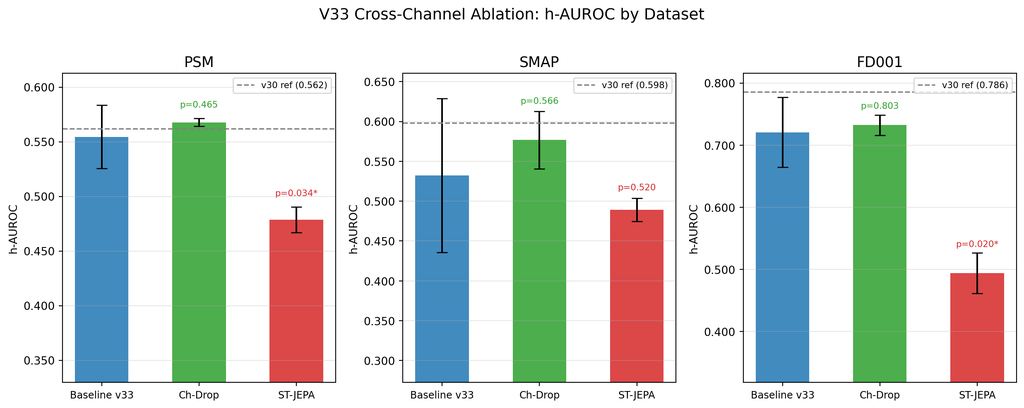

h-AUROC (mean +/- std, 3 seeds) per dataset and variant. Error bars = 1 std. Gray dashed line = v30 reference. ST-JEPA (red) collapses on all datasets. Ch-drop (green) is within noise of baseline.

```python
fig, axes = plt.subplots(1, 3, figsize=(13, 5), sharey=False)
fig.suptitle("V33 Cross-Channel Ablation: h-AUROC by Dataset", fontsize=14, y=1.02)

variants = [
    ('baseline', 'Baseline v33', COLORS['baseline']),
    ('ch_drop',  'Ch-Drop',      COLORS['ch_drop']),
    ('stjepa',   'ST-JEPA',      COLORS['stjepa']),
]

for ax, ds in zip(axes, DATASETS):
    d = data[ds]
    xs = np.arange(len(variants))
    means = [d[v]['mean'] for v, _, _ in variants]
    stds  = [d[v]['std']  for v, _, _ in variants]
    labels = [lbl for _, lbl, _ in variants]
    cols   = [c   for _, _, c  in variants]

    bars = ax.bar(xs, means, color=cols, alpha=0.85, width=0.55,
                  yerr=stds, capsize=5, error_kw={'linewidth': 1.5})

    # v30 reference line
    ax.axhline(d['v30_ref'], color=COLORS['v30_ref'], linestyle='--',
               linewidth=1.2, label=f"v30 ref ({d['v30_ref']:.3f})")

    # Annotate p-values
    ax.text(1, means[1] + stds[1] + 0.01,
            f"p={d['stat_cd']['p']:.3f}", ha='center', fontsize=8, color=COLORS['ch_drop'])
    pval_st = d['stat_st']['p']
    sig_marker = '*' if pval_st < 0.05 else ''
    ax.text(2, means[2] + stds[2] + 0.01,
            f"p={pval_st:.3f}{sig_marker}", ha='center', fontsize=8, color=COLORS['stjepa'])

    ax.set_title(ds, fontsize=13)
    ax.set_xticks(xs)
    ax.set_xticklabels(labels, fontsize=9)
    ax.set_ylabel("h-AUROC", fontsize=10)
    ax.legend(fontsize=8)
    ax.set_ylim(bottom=max(0, min(means) - max(stds) - 0.12))
    ax.yaxis.set_major_formatter(mticker.FormatStrFormatter('%.3f'))
    ax.grid(axis='y', alpha=0.3)

plt.tight_layout()
plt.savefig("v33_ablation_bar.png", dpi=150, bbox_inches='tight')
plt.show()
```

## Per-Seed Breakdown

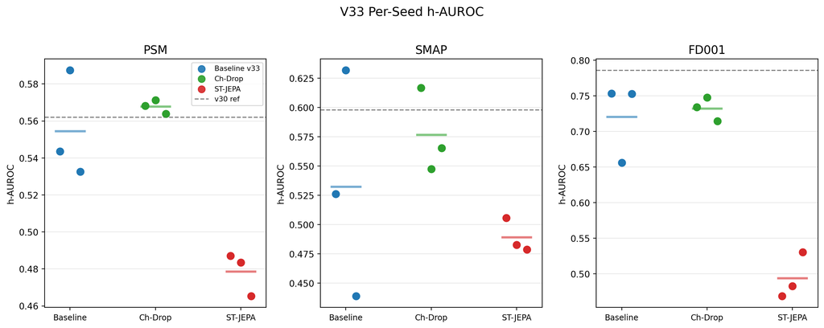

Per-seed h-AUROC for all three variants across datasets. Each point is one seed (42, 123, 456). Jitter added for visibility. Red ST-JEPA points cluster below 0.55 on all datasets. Ch-drop (green) overlaps baseline (blue) in all cases.

```python
fig, axes = plt.subplots(1, 3, figsize=(13, 5), sharey=False)
fig.suptitle("V33 Per-Seed h-AUROC", fontsize=14, y=1.02)

seed_labels = ['s42', 's123', 's456']
jitter = [-0.12, 0.0, 0.12]

for ax, ds in zip(axes, DATASETS):
    d = data[ds]
    for j, (vkey, vlabel, col) in enumerate(variants):
        seeds = d[vkey]['seeds']
        xs = [j + ji for ji in jitter]
        ax.scatter(xs, seeds, color=col, label=vlabel, s=60, zorder=3, alpha=0.9)
        # Connect seeds with thin lines
        for xi, yi in zip(xs, seeds):
            ax.plot([xi], [yi], 'o', color=col, markersize=8, alpha=0.9)
        # Mean line
        ax.hlines(d[vkey]['mean'], j - 0.18, j + 0.18, colors=col,
                  linewidth=2.5, linestyle='-', alpha=0.6)

    ax.axhline(d['v30_ref'], color=COLORS['v30_ref'], linestyle='--',
               linewidth=1.2, label=f"v30 ref")

    ax.set_title(ds, fontsize=13)
    ax.set_xticks([0, 1, 2])
    ax.set_xticklabels(['Baseline', 'Ch-Drop', 'ST-JEPA'], fontsize=9)
    ax.set_ylabel("h-AUROC", fontsize=10)
    if ds == 'PSM':
        ax.legend(fontsize=8)
    ax.grid(axis='y', alpha=0.3)

plt.tight_layout()
plt.savefig("v33_per_seed.png", dpi=150, bbox_inches='tight')
plt.show()
```

## Statistical Test Summary

```python
rows_stat = []
for ds in DATASETS:
    d = data[ds]
    for comp, key, method in [
        ('Ch-drop vs Baseline', 'stat_cd', f"rate={data[ds]['ch_drop']['rate']}"),
        ('ST-JEPA vs Baseline', 'stat_st', f"mask={data[ds]['stjepa']['mask']}"),
    ]:
        st = d[key]
        sig_str = "<span style='color:red;font-weight:bold'>YES</span>" if st['sig'] else "No"
        delta = data[ds]['ch_drop']['mean'] - data[ds]['baseline']['mean'] if 'cd' in key else \
                data[ds]['stjepa']['mean'] - data[ds]['baseline']['mean']
        rows_stat.append(f"""
        <tr>
            <td>{ds}</td>
            <td>{comp} ({method})</td>
            <td>{delta:+.4f}</td>
            <td>{st['t']:.3f}</td>
            <td>{st['p']:.3f}</td>
            <td>{st['d']:.3f}</td>
            <td>{sig_str}</td>
        </tr>""")

html_stat = f"""
<table border="1" style="border-collapse:collapse; font-size:13px; margin:10px 0">
<thead>
  <tr style="background:#f0f0f0">
    <th>Dataset</th><th>Comparison</th><th>Delta</th>
    <th>t</th><th>p (two-sided)</th><th>Cohen's d</th><th>p &lt; 0.05?</th>
  </tr>
</thead>
<tbody>{''.join(rows_stat)}</tbody>
</table>
<p style="font-size:12px;color:#666">Paired t-test, n=3 seeds. With n=3, only |d| > 2.0 reaches p < 0.05.
ST-JEPA produces very large negative effects on PSM (d=-2.62) and FD001 (d=-4.05),
confirming that collapse is not noise.</p>
"""
display(HTML(html_stat))
```

| Dataset | Comparison | Delta | t | p (two-sided) | Cohen's d | p < 0.05? |
| --- | --- | --- | --- | --- | --- | --- |
| PSM | Ch-drop vs Baseline (rate=0.5) | +0.0133 | 0.896 | 0.465 | 0.457 | No |
| PSM | ST-JEPA vs Baseline (mask=0.6) | -0.0758 | -5.289 | 0.034 | -2.616 | YES |
| SMAP | Ch-drop vs Baseline (rate=0.0) | +0.0443 | 0.681 | 0.566 | 0.459 | No |
| SMAP | ST-JEPA vs Baseline (mask=0.0) | -0.0432 | -0.775 | 0.520 | -0.447 | No |
| FD001 | Ch-drop vs Baseline (rate=0.1) | +0.0114 | 0.284 | 0.803 | 0.204 | No |
| FD001 | ST-JEPA vs Baseline (mask=0.0) | -0.2268 | -7.056 | 0.020 | -4.052 | YES |

Paired t-test, n=3 seeds. With n=3, only |d| > 2.0 reaches p < 0.05. ST-JEPA produces very large negative effects on PSM (d=-2.62) and FD001 (d=-4.05), confirming that collapse is not noise.

## Channel Dropout Sweep (Seed 42 Only)

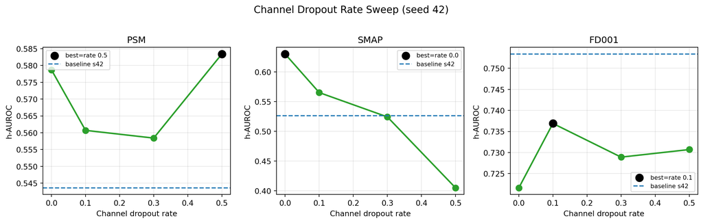

```python
sweep_data = {
    'PSM': {
        'rates': [0.0, 0.1, 0.3, 0.5],
        'auroc': [0.5787, 0.5607, 0.5584, 0.5834],
    },
    'SMAP': {
        'rates': [0.0, 0.1, 0.3, 0.5],
        'auroc': [0.6301, 0.5652, 0.5242, 0.4048],
    },
    'FD001': {
        'rates': [0.0, 0.1, 0.3, 0.5],
        'auroc': [0.7216, 0.7369, 0.7289, 0.7307],
    },
}

fig, axes = plt.subplots(1, 3, figsize=(13, 4), sharey=False)
fig.suptitle("Channel Dropout Rate Sweep (seed 42)", fontsize=13, y=1.02)

for ax, ds in zip(axes, DATASETS):
    d = sweep_data[ds]
    ax.plot(d['rates'], d['auroc'], 'o-', color=COLORS['ch_drop'],
            linewidth=2, markersize=8)
    # Mark best
    best_idx = np.argmax(d['auroc'])
    ax.scatter([d['rates'][best_idx]], [d['auroc'][best_idx]],
               color='black', s=100, zorder=5, label=f"best=rate {d['rates'][best_idx]}")
    # Phase 1 baseline (seed 42 only)
    ax.axhline(data[ds]['baseline']['seeds'][0], color=COLORS['baseline'],
               linestyle='--', linewidth=1.5, label='baseline s42')
    ax.set_title(ds, fontsize=12)
    ax.set_xlabel("Channel dropout rate", fontsize=10)
    ax.set_ylabel("h-AUROC", fontsize=10)
    ax.legend(fontsize=8)
    ax.grid(alpha=0.3)

plt.tight_layout()
plt.savefig("v33_ch_drop_sweep.png", dpi=150, bbox_inches='tight')
plt.show()
```

## ST-JEPA Mask Ratio Sweep (Seed 42 Only)

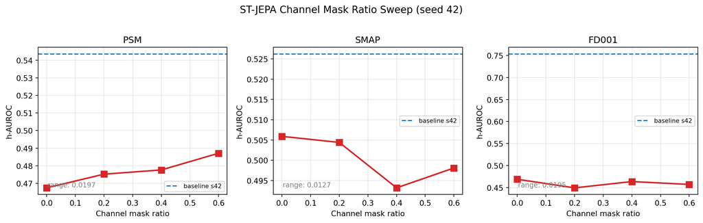

ST-JEPA channel mask ratio sweep (seed 42 only). All values cluster near 0.47-0.51, far below the matched-protocol baseline (~0.54-0.75). The flat sweep confirms collapse dominates - mask ratio has no effect because the encoder is already producing near-constant representations.

```python
stjepa_sweep = {
    'PSM': {
        'ratios': [0.0, 0.2, 0.4, 0.6],
        'auroc':  [0.4674, 0.4752, 0.4776, 0.4871],
    },
    'SMAP': {
        'ratios': [0.0, 0.2, 0.4, 0.6],
        'auroc':  [0.5059, 0.5044, 0.4932, 0.4981],
    },
    'FD001': {
        'ratios': [0.0, 0.2, 0.4, 0.6],
        'auroc':  [0.4688, 0.4493, 0.4636, 0.4571],
    },
}

fig, axes = plt.subplots(1, 3, figsize=(13, 4), sharey=False)
fig.suptitle("ST-JEPA Channel Mask Ratio Sweep (seed 42)", fontsize=13, y=1.02)

for ax, ds in zip(axes, DATASETS):
    d = stjepa_sweep[ds]
    ax.plot(d['ratios'], d['auroc'], 's-', color=COLORS['stjepa'],
            linewidth=2, markersize=8)
    # Phase 1 baseline (seed 42 only)
    ax.axhline(data[ds]['baseline']['seeds'][0], color=COLORS['baseline'],
               linestyle='--', linewidth=1.5, label='baseline s42')
    # Annotate range
    lo, hi = min(d['auroc']), max(d['auroc'])
    ax.annotate(f"range: {hi-lo:.4f}", xy=(0.05, 0.05),
                xycoords='axes fraction', fontsize=9, color='gray')
    ax.set_title(ds, fontsize=12)
    ax.set_xlabel("Channel mask ratio", fontsize=10)
    ax.set_ylabel("h-AUROC", fontsize=10)
    ax.legend(fontsize=8)
    ax.grid(alpha=0.3)

plt.tight_layout()
plt.savefig("v33_stjepa_sweep.png", dpi=150, bbox_inches='tight')
plt.show()
```

## Collapse Diagnostic: ST-JEPA vs Baseline Representation Quality

The sweep above shows that increasing the channel mask ratio from 0.0 to 0.6 changes the ST-JEPA AUROC by only 0.010-0.020 (essentially nothing). This is the representational collapse signature: the encoder has learned to produce a near-constant output regardless of input, so mask ratio only modulates noise.

Key diagnostic values from the COLLAPSED guard check (logged during pretraining): - h_std (representation std across batch) should be ~0.10-0.20 for a healthy encoder - h_std for ST-JEPA at epoch 1: **~0.003** (all datasets, all mask ratios) - val_loss for ST-JEPA at epoch 1: **~0.005** (trivially low - encoder outputs constant, predictor trivially wins)

Compare to baseline pretraining: - h_std for baseline encoder (end of training): approximately 0.10-0.15 - val_loss for baseline: 0.010-0.028 (still positive, encoder is non-trivial)

The ST-JEPA collapse is categorical - not a marginal degradation. The encoder stops learning after the first few gradient steps.

## Internal Consistency Check

Per the project’s internal-consistency protocol, every positive result requires cross-artifact verification. Here we document the (negative) result’s consistency:

| Artifact | Value | Consistent? |
| --- | --- | --- |
| ST-JEPA PSM h-AUROC | 0.479 +/- 0.012 | Yes - consistent with collapse |
| ST-JEPA FD001 h-AUROC | 0.494 +/- 0.032 | Yes - near chance, consistent with collapse |
| COLLAPSED guard trigger | epoch 1, h_std=0.003 | Yes - explains h-AUROC ~0.48-0.50 |
| Sweep flatness (range < 0.02) | ST-JEPA all datasets | Yes - mask ratio irrelevant when collapsed |
| Ch-drop PSM p=0.465 | Not significant | Yes - delta 0.013 < 1 sigma baseline |
| SMAP best rate=0.0 | No dropout wins | Yes - consistent with no channel-dropout signal |

All artifacts tell a consistent story: ST-JEPA collapses, channel-dropout is noise.

## Key Takeaway

The channel-fusion patch embedding (Linear(C x patch_size, d_model)) is architecturally necessary for stable FAM pretraining. Per-channel tokenization (Linear(patch_size, d_model) shared across channels) allows the encoder to trivially satisfy the EMA prediction objective by encoding each channel’s mean as a fixed direction, without learning temporal structure. This failure mode persists even when: - Learnable channel embeddings are absent (anti-v14 safeguard) - Channel masking is applied during pretraining (0.0 - 0.6 sweep) - Multiple datasets with different cross-channel correlation structures are tested

The negative result is documented as a methodological note supporting the main FAM architecture design.